# Proyecto_Final

Suhan_Juárez

11/16/2021

## 0.1 Transcribir ADN a ARN

*Ejercicio a resolver*: A partir de una secuencia de al menos 1000 pb se debe Transcribir de ADN a ARN.

El problema implica sustituir la Timina, sólo en el ADN por Uracilo en ARN. Vamos a empezar con una cadena pequeña que contenga las cuatro bases, en un primer ejemplo:

```r
library(Biostrings)
A<-DNAString("AGCT")
A
```

```
## 4-letter DNAString object
## seq: AGCT
```

Ahora la transformamos en un vector para trabajar con ella, ya que sino se leerá como cadena de ADN del paquete.

```r
A<-as.vector(A)
class(A)  #Revisamos sus características
```

```
## [1] "factor"
```

```r
length(A) #Tamaño
```

```
## [1] 4
```

```r
A
```

```
## [1] A G C T
## Levels: A C G T M R W S Y K V H D B N - + .
```

Aquí hay una característica importante, ya que la secuencia se tomó desde un programa base ya tiene niveles definidos…

```r
levels(A)
```

```
##  [1] "A" "C" "G" "T" "M" "R" "W" "S" "Y" "K" "V" "H" "D" "B" "N" "-" "+" "."
```

Si deseamos reemplzar T por U, éste último no se encuentra en los niveles y no lo reemplzará. Por ello vamos a agregar ese nivel con el siguiente código:

```r
levels(A)<-c(levels(A),"U")
levels(A)
```

```
##  [1] "A" "C" "G" "T" "M" "R" "W" "S" "Y" "K" "V" "H" "D" "B" "N" "-" "+" "." "U"
```

Ya que lo tenemos agregado, vamos a usar which para conocer la posición de las T en el vector. Y lo guardamos en un objeto.

```r
Tpos<-which(A=="T")
Tpos
```

```
## [1] 4
```

Ahora simplmente usamos la función replace para sutituirlo y listo

```r
replace(A,Tpos,"U")
```

```
## [1] A G C U
## Levels: A C G T M R W S Y K V H D B N - + . U
```

Ahora vamos a usar una secuencia de nucleotidos bajada del NCBI, de una especie de Bacillus con los 1000 nucleotidos. En secuencias grandes, por el tipo de datos, no se puede aplicar lo anterior, por ello, se puede unar una simple función de sustitución.

```r
SeqBacillus<-readDNAStringSet("01_Raw_Data/Bacillus_pseudomycoides.fasta")
SeqBacillus
```

```
## DNAStringSet object of length 1:
##     width seq                                               names
## [1]  1000 ATGAATAAGAGGCTTTATAAGAA...CAGTCCTGAGGAGTTTACTTTTA NZ_CM000745.1:168...
```

```r
RNABacillus<-gsub("T","U",SeqBacillus)
RNABacillus
```

```
##                                                                                                                                                                                                                                                                                                          …
## "AUGAAUAAGAGGCUUUAUAAGAAAAUCAUGUUGUCAAUGAUGGUUCUUGGGGUUACGACA…"
```

## 0.2 Transcribir RNA en proteina

*Ejercicio a resolver*: A partir de una secuencia de ARN Transcribir a proteína.

Usamos la siguiente secuencia:

```r
Mirounga<-readDNAStringSet("01_Raw_Data/Mirounga_MYD88.fasta")
Mirounga<-as.matrix(Mirounga)
Mirounga<-as.vector(Mirounga)
Mirounga
```

```
##    [1] "A" "A" "C" "A" "G" "A" "A" "A" "C" "C" "G" "G" "C" "G" "G" "G" "G" "C"
##   [19] "T" "G" "G" "G" "C" "C" "G" "G" "G" "G" "G" "C" "G" "G" "G" "G" "A" "T"
##   [37] "G" "G" "C" "G" "G" "T" "A" "A" "A" "G" "G" "A" "A" "G" "G" "A" "G" "G"
##   [55] "A" "A" "G" "C" "G" "C" "G" "G" "A" "C" "A" "G" "G" "C" "G" "A" "C" "G"
##   [73] "C" "A" "A" "C" "T" "C" "C" "A" "C" "A" "G" "C" "G" "C" "T" "G" "G" "G"
##   [91] "G" "C" "T" "C" "C" "G" "G" "G" "G" "G" "T" "A" "T" "C" "C" "C" "A" "C"
##  [109] "C" "A" "T" "G" "G" "C" "T" "G" "C" "A" "G" "A" "A" "G" "T" "C" "T" "C"
##  [127] "C" "C" "G" "C" "G" "C" "G" "G" "A" "G" "T" "C" "C" "G" "C" "G" "T" "C"
##  [145] "C" "C" "C" "C" "G" "C" "C" "T" "G" "C" "T" "C" "C" "A" "T" "G" "T" "C"
##  [163] "C" "T" "C" "C" "C" "T" "G" "C" "C" "G" "C" "T" "G" "G" "C" "T" "G" "C"
##  [181] "T" "C" "T" "C" "A" "A" "C" "G" "T" "G" "C" "G" "A" "G" "T" "G" "C" "G"
##  [199] "G" "C" "G" "C" "C" "G" "C" "C" "T" "G" "T" "C" "G" "C" "T" "G" "T" "T"
##  [217] "C" "C" "T" "G" "A" "A" "C" "G" "T" "G" "C" "G" "G" "A" "C" "G" "C" "A"
##  [235] "G" "G" "T" "G" "G" "C" "G" "G" "C" "C" "G" "A" "T" "T" "G" "G" "A" "C"
##  [253] "C" "G" "C" "G" "C" "T" "G" "G" "C" "C" "G" "A" "G" "G" "A" "G" "A" "T"
```

[output cut: 95 more lines]

```r
RNAMirounga<-gsub("T","U",Mirounga)
RNAMirounga
```

```
##    [1] "A" "A" "C" "A" "G" "A" "A" "A" "C" "C" "G" "G" "C" "G" "G" "G" "G" "C"
##   [19] "U" "G" "G" "G" "C" "C" "G" "G" "G" "G" "G" "C" "G" "G" "G" "G" "A" "U"
##   [37] "G" "G" "C" "G" "G" "U" "A" "A" "A" "G" "G" "A" "A" "G" "G" "A" "G" "G"
##   [55] "A" "A" "G" "C" "G" "C" "G" "G" "A" "C" "A" "G" "G" "C" "G" "A" "C" "G"
##   [73] "C" "A" "A" "C" "U" "C" "C" "A" "C" "A" "G" "C" "G" "C" "U" "G" "G" "G"
##   [91] "G" "C" "U" "C" "C" "G" "G" "G" "G" "G" "U" "A" "U" "C" "C" "C" "A" "C"
##  [109] "C" "A" "U" "G" "G" "C" "U" "G" "C" "A" "G" "A" "A" "G" "U" "C" "U" "C"
##  [127] "C" "C" "G" "C" "G" "C" "G" "G" "A" "G" "U" "C" "C" "G" "C" "G" "U" "C"
##  [145] "C" "C" "C" "C" "G" "C" "C" "U" "G" "C" "U" "C" "C" "A" "U" "G" "U" "C"
##  [163] "C" "U" "C" "C" "C" "U" "G" "C" "C" "G" "C" "U" "G" "G" "C" "U" "G" "C"
##  [181] "U" "C" "U" "C" "A" "A" "C" "G" "U" "G" "C" "G" "A" "G" "U" "G" "C" "G"
##  [199] "G" "C" "G" "C" "C" "G" "C" "C" "U" "G" "U" "C" "G" "C" "U" "G" "U" "U"
##  [217] "C" "C" "U" "G" "A" "A" "C" "G" "U" "G" "C" "G" "G" "A" "C" "G" "C" "A"
##  [235] "G" "G" "U" "G" "G" "C" "G" "G" "C" "C" "G" "A" "U" "U" "G" "G" "A" "C"
##  [253] "C" "G" "C" "G" "C" "U" "G" "G" "C" "C" "G" "A" "G" "G" "A" "G" "A" "U"
```

[output cut: 95 more lines]

NOTA: Se transform los datos para poder acceder y trabajar con ellos

Haremos VECTORES que corresponden a los codones para poder trabajar con los datos de la secuencia y que se comparen

```r
F1<-c("U","U","U")
F2<-c("U","U","C")
L1<-c("U","U","A")
L2<-c("U","U","G")
L3<-c("C","U","U")
L4<-c("C","U","C")
L5<-c("C","U","A")
L6<-c("C","U","G")
I1<-c("A","U","U")
I2<-c("A","U","C")
I3<-c("A","U","A")
M1<-c("A","U","G")
V1<-c("G","U","U")
V2<-c("C","C","C")
V3<-c("G","U","A")
V4<-c("G","U","G")
S1<-c("U","C","U")
S2<-c("G","U","C")
S3<-c("U","C","A")
S4<-c("U","C","G")
P1<-c("C","C","U")
P2<-c("C","C","C")
P3<-c("C","C","A")
P4<-c("C","C","G")
T1<-c("A","C","U")
T2<-c("A","C","C")
T3<-c("A","C","A")
T4<-c("A","C","G")
A1<-c("G","C","U")
A2<-c("G","C","C")
A3<-c("G","C","A")
A4<-c("G","C","G")
Y1<-c("U","A","U")
Y2<-c("U","A","C")
STOP1<-c("U","A","A")
STOP2<-c("U","A","G")
STOP3<-c("U","G","A")
H1<-c("C","A","U")
H2<-c("C","A","C")
Q1<-c("C","A","A")
Q2<-c("C","A","G")
N1<-c("A","A","U")
N2<-c("A","A","C")
K1<-c("A","A","A")
K2<-c("A","A","G")
D1<-c("G","A","U")
D2<-c("G","A","C")
E1<-c("G","A","A")
E2<-c("G","A","G")
C1<-c("U","G","U")
C2<-c("U","A","C")
W1<-c("U","G","G")
R1<-c("C","G","U")
R2<-c("C","G","C")
R3<-c("C","G","A")
R4<-c("C","G","G")
R5<-c("A","G","A")
R6<-c("A","G","G")
S1<-c("A","G","U")
S2<-c("A","G","C")
G1<-c("G","G","U")
G2<-c("G","G","C")
G3<-c("G","G","A")
G4<-c("G","G","G")
```

Fragmentamos RNAMirounga para que cada codón sea leído y reemplazado por el aa correspondiente

```r
Frag_RNAMirounga<-split(RNAMirounga, ceiling(seq_along(RNAMirounga)/3))
```

Creamos un vector vacío para que se guarde la sec de proteínas Empleamos el siguiente Script para determinar la secuencia de aminácidos:

```r
ProtMirounga<-c()
for (codon in Frag_RNAMirounga) {

  if (all(codon == F1) | all(codon == F2)) {
    ProtMirounga<-c(ProtMirounga, "F")
  } else if (all(codon == L1) | all(codon == L2) | all(codon == L3) | all(codon == L4) | all(codon == L5) | all(codon == L6)) {
    ProtMirounga<-c(ProtMirounga, "L")
  } else if (all(codon == I1) | all(codon == I2) | all(codon == I3)) {
    ProtMirounga<-c(ProtMirounga, "I")
  } else if (all(codon == M1)) {
    ProtMirounga<-c(ProtMirounga, "M")
  } else if (all(codon == V1) | all(codon == V2) | all(codon == V3) | all(codon == V4)) {
    ProtMirounga<-c(ProtMirounga, "V")
  } else if (all(codon == S1) | all(codon == S2) | all(codon == S3) | all(codon == S4)) {
    ProtMirounga<-c(ProtMirounga, "S")
  } else if (all(codon == P1) | all(codon == P2) | all(codon == P3) | all(codon == P4)) {
    ProtMirounga<-c(ProtMirounga, "P")
  } else if (all(codon == T1) | all(codon == T2) | all(codon == T3) | all(codon == T4)) {
    ProtMirounga<-c(ProtMirounga, "T")
  } else if (all(codon == A1) | all(codon == A2) | all(codon == A3) | all(codon == A4)) {
    ProtMirounga<-c(ProtMirounga, "A")
  } else if (all(codon == Y1) | all(codon == Y2)) {
    ProtMirounga<-c(ProtMirounga, "Y")
  } else if (all(codon == STOP1) | all(codon == STOP2) | all(codon == STOP3)) {
    ProtMirounga<-c(ProtMirounga, "STOP")
  } else if (all(codon == H1) | all(codon == H2)) {
    ProtMirounga<-c(ProtMirounga, "H")
  } else if (all(codon == Q1) | all(codon == Q2)) {
    ProtMirounga<-c(ProtMirounga, "Q")
  } else if (all(codon == N1) | all(codon == N2)) {
    ProtMirounga<-c(ProtMirounga, "N")
  } else if (all(codon == K1) | all(codon == K2)) {
    ProtMirounga<-c(ProtMirounga, "K")
  } else if (all(codon == D1) | all(codon == D2)) {
    ProtMirounga<-c(ProtMirounga, "D")
  } else if (all(codon == E1) | all(codon == E2)) {
    ProtMirounga<-c(ProtMirounga, "E")
  } else if (all(codon == C1) | all(codon == C2)) {
    ProtMirounga<-c(ProtMirounga, "C")
  } else if (all(codon == W1)) {
    ProtMirounga<-c(ProtMirounga, "W")
  } else if (all(codon == R1) | all(codon == R2) | all(codon == R3) | all(codon == R4) | all(codon == R5) | all(codon == R6)) {
    ProtMirounga<-c(ProtMirounga, "R")
  } else if (all(codon == S1) | all(codon == S2)) {
    ProtMirounga<-c(ProtMirounga, "S")
  } else if (all(codon == G1) | all(codon == G2) | all(codon == G3) | all(codon == G4)) {
    ProtMirounga<-c(ProtMirounga, "G")
  } else {
    ProtMirounga<-c(ProtMirounga, codon)
  }

}

ProtMirounga
```

```
##   [1] "N"    "R"    "N"    "R"    "R"    "G"    "W"    "A"    "G"    "G"
##  [11] "G"    "D"    "G"    "G"    "K"    "G"    "R"    "R"    "K"    "R"
##  [21] "G"    "Q"    "A"    "T"    "Q"    "L"    "H"    "S"    "A"    "G"
##  [31] "A"    "P"    "G"    "V"    "U"    "C"    "C"    "H"    "H"    "G"
##  [41] "U"    "G"    "C"    "R"    "S"    "L"    "P"    "R"    "G"    "G"
##  [51] "U"    "C"    "R"    "G"    "U"    "C"    "V"    "R"    "L"    "L"
##  [61] "H"    "G"    "U"    "C"    "L"    "P"    "A"    "A"    "G"    "U"
##  [71] "G"    "C"    "U"    "C"    "U"    "Q"    "R"    "A"    "S"    "A"
##  [81] "A"    "P"    "P"    "G"    "U"    "C"    "A"    "V"    "P"    "E"
##  [91] "R"    "A"    "D"    "A"    "G"    "G"    "G"    "R"    "L"    "D"
## [101] "R"    "A"    "G"    "R"    "G"    "D"    "G"    "L"    "R"    "V"
## [111] "L"    "G"    "D"    "P"    "A"    "U"    "C"    "U"    "G"    "D"
## [121] "A"    "R"    "R"    "V"    "H"    "G"    "Q"    "A"    "A"    "G"
## [131] "R"    "L"    "A"    "G"    "T"    "V"    "W"    "R"    "L"    "G"
## [141] "G"    "P"    "P"    "A"    "STOP" "A"    "A"    "H"    "Q"    "A"
```

[output cut: 61 more lines]

Abrimos la paquetería correspondiente para transformar y guardar nuestros datos de la secuencia de proteínas. En un formato necesario, como es FASTA.

```r
library(gridExtra)
library(datasets)
library(seqinr)
setwd("03_Output/Processed data/") ##Nos posicionamos en la carpeta correspondiente, de salida de datos
write.fasta(sequences = ProtMirounga,names = "Mirounga_MyD88",file.out="MyD88_aa_NES.fasta")
dev.off()
```

## 0.3 Localizar sitios de restricción

*Ejercicio a resolver*: A partir de una secuencia de al menos 1000 pb ubicar la posición y longitud de cada palindromo inverso en la cadena. El palindromo inverso: serán secuencias que tienen la misma secuencia en su complemento(de dercha a izquierda).

Primero cargamos una secuencia de 1000 pb:

```r
library(Biostrings)
Bacillus<-readDNAStringSet("01_Raw_Data/Bacillus_pseudomycoides.fasta")
Bacillus
```

```
## DNAStringSet object of length 1:
##     width seq                                               names
## [1]  1000 ATGAATAAGAGGCTTTATAAGAA...CAGTCCTGAGGAGTTTACTTTTA NZ_CM000745.1:168...
```

```r
Bac_matrix<-as.matrix(Bacillus)
Sec_Bacillus<-as.vector(Bac_matrix)
length(Sec_Bacillus)
```

```
## [1] 1000
```

Primero necesitamos la cadena complementaria (C-G y A-T), yo usé lo siguiente. Además, buscamos la posición de las bases y después un reemplazo por el complementario.

```r
Adenin<-which(Sec_Bacillus =="A")
Adenin
```

```
##   [1]    1    4    5    7    8   10   17   19   20   22   23   24   25   28   36
##  [16]   37   40   55   58   60   61   64   65   67   72   75   80   90   93   95
##  [31]   96   98   99  100  101  107  108  109  111  113  117  122  123  125  126
##  [46]  127  130  131  133  134  135  136  137  140  156  159  164  167  171  172
##  [61]  177  179  180  181  183  184  186  190  195  201  202  206  210  212  217
##  [76]  218  219  220  222  223  230  233  234  236  237  239  240  241  243  245
##  [91]  250  253  254  255  256  258  259  264  267  268  269  271  274  279  282
## [106]  284  285  286  287  289  292  295  296  299  302  303  304  305  306  308
## [121]  313  314  319  320  325  327  329  336  338  341  342  343  346  347  348
## [136]  353  354  355  361  362  364  368  371  372  373  374  376  383  384  388
## [151]  389  392  394  396  401  402  405  407  410  412  413  415  416  420  423
## [166]  426  430  434  437  438  439  440  441  443  445  451  452  453  457  458
## [181]  459  464  468  470  471  472  473  474  479  481  482  487  493  494  496
## [196]  497  500  502  506  507  512  514  515  522  525  526  527  531  532  533
## [211]  534  535  543  544  545  547  549  550  555  557  558  560  562  564  565
## [226]  566  567  568  574  575  578  581  585  586  587  590  591  594  595  600
## [241]  601  606  609  610  613  616  617  624  625  638  639  641  644  645  646
## [256]  649  650  652  656  658  659  662  666  667  670  671  672  673  674  675
## [271]  676  679  680  683  685  691  699  702  705  720  721  724  745  748  760
## [286]  761  763  764  765  767  769  774  775  776  780  782  783  786  788  789
## [301]  790  794  795  796  797  801  802  803  808  810  811  822  824  830  831
## [316]  834  838  844  848  853  854  855  856  857  859  860  862  864  865  868
## [331]  869  871  874  878  879  880  882  883  887  891  895  898  908  909  910
## [346]  911  913  915  919  920  923  929  931  933  934  939  943  944  947  949
## [361]  950  952  953  962  963  964  965  969  970  971  972  976  979  986  989
## [376]  994 1000
```

```r
Timin<-which(Sec_Bacillus =="T")
Timin
```

```
##   [1]   2   6  14  15  16  18  26  29  31  32  34  38  41  44  45  47  48  53
##  [19]  54  63  66  68  69  71  77  81  84  86  87 110 114 115 118 119 132 139
##  [37] 141 142 144 146 147 150 153 160 161 168 170 173 187 189 192 194 196 197
##  [55] 198 203 207 211 213 224 225 228 231 246 247 248 252 257 261 266 270 273
##  [73] 276 277 278 288 290 293 316 317 321 326 328 331 334 335 339 344 351 356
##  [91] 357 358 359 369 375 377 378 380 385 386 387 390 393 397 398 406 408 409
## [109] 417 418 419 421 422 429 431 454 455 460 462 465 466 467 475 476 478 483
## [127] 485 488 489 490 491 504 509 513 518 520 521 528 530 538 539 540 546 551
## [145] 561 571 572 573 579 582 588 592 593 598 602 603 604 605 612 618 621 626
## [163] 627 632 634 635 647 651 654 655 660 663 664 668 669 678 681 684 686 689
## [181] 690 692 693 707 708 709 711 713 718 719 722 726 727 729 731 735 738 746
## [199] 749 750 753 755 759 768 770 771 777 791 799 800 807 812 813 814 816 833
## [217] 837 839 840 841 842 846 849 851 852 858 866 870 872 884 885 888 896 897
## [235] 900 901 903 905 906 912 914 916 921 925 928 930 935 936 946 948 951 954
## [253] 955 956 958 959 966 968 977 981 984 991 992 993 996 997 998 999
```

```r
Citocin<-which(Sec_Bacillus =="C")
Citocin
```

```
##   [1]  13  27  35  46  56  59  73  74  76  79  82  83  85  89  92  97 106 112
##  [19] 116 121 129 138 143 145 151 152 155 162 163 176 178 182 185 188 200 209
##  [37] 215 221 226 232 235 242 263 280 294 298 300 301 311 312 323 330 349 350
##  [55] 352 365 370 395 399 400 404 411 414 425 428 435 436 444 447 461 480 486
##  [73] 495 498 499 517 529 536 541 554 563 570 584 589 596 597 599 608 614 620
##  [91] 628 629 631 637 640 643 648 653 657 665 695 701 704 706 716 723 725 730
## [109] 732 734 742 743 752 756 758 773 779 784 792 798 806 815 821 823 827 836
## [127] 845 863 867 875 881 890 893 894 899 902 904 907 917 922 932 941 961 975
## [145] 978 982 983 995
```

```r
Guanin<-which(Sec_Bacillus =="G")
Guanin
```

```
##   [1]   3   9  11  12  21  30  33  39  42  43  49  50  51  52  57  62  70  78
##  [19]  88  91  94 102 103 104 105 120 124 128 148 149 154 157 158 165 166 169
##  [37] 174 175 191 193 199 204 205 208 214 216 227 229 238 244 249 251 260 262
##  [55] 265 272 275 281 283 291 297 307 309 310 315 318 322 324 332 333 337 340
##  [73] 345 360 363 366 367 379 381 382 391 403 424 427 432 433 442 446 448 449
##  [91] 450 456 463 469 477 484 492 501 503 505 508 510 511 516 519 523 524 537
## [109] 542 548 552 553 556 559 569 576 577 580 583 607 611 615 619 622 623 630
## [127] 633 636 642 661 677 682 687 688 694 696 697 698 700 703 710 712 714 715
## [145] 717 728 733 736 737 739 740 741 744 747 751 754 757 762 766 772 778 781
## [163] 785 787 793 804 805 809 817 818 819 820 825 826 828 829 832 835 843 847
## [181] 850 861 873 876 877 886 889 892 918 924 926 927 937 938 940 942 945 957
## [199] 960 967 973 974 980 985 987 988 990
```

```r
Complement<-replace(Sec_Bacillus,Adenin,"T")
Complement<-replace(Complement,Timin,"A")
Complement<-replace(Complement,Citocin,"G")
Complement<-replace(Complement,Guanin,"C")
```

Guardamos en un objeto esto:

```r
Complement
```

```
##    [1] "T" "A" "C" "T" "T" "A" "T" "T" "C" "T" "C" "C" "G" "A" "A" "A" "T" "A"
##   [19] "T" "T" "C" "T" "T" "T" "T" "A" "G" "T" "A" "C" "A" "A" "C" "A" "G" "T"
##   [37] "T" "A" "C" "T" "A" "C" "C" "A" "A" "G" "A" "A" "C" "C" "C" "C" "A" "A"
##   [55] "T" "G" "C" "T" "G" "T" "T" "C" "A" "T" "T" "A" "T" "A" "A" "C" "A" "T"
##   [73] "G" "G" "T" "G" "A" "C" "G" "T" "A" "G" "G" "A" "G" "A" "A" "C" "G" "T"
##   [91] "C" "G" "T" "C" "T" "T" "G" "T" "T" "T" "T" "C" "C" "C" "C" "G" "T" "T"
##  [109] "T" "A" "T" "G" "T" "A" "A" "G" "T" "A" "A" "C" "G" "T" "T" "C" "T" "T"
##  [127] "T" "C" "G" "T" "T" "A" "T" "T" "T" "T" "T" "G" "A" "T" "A" "A" "G" "A"
##  [145] "G" "A" "A" "C" "C" "A" "G" "G" "A" "C" "G" "T" "C" "C" "T" "A" "A" "G"
##  [163] "G" "T" "C" "C" "T" "A" "C" "A" "T" "T" "A" "C" "C" "G" "T" "G" "T" "T"
##  [181] "T" "G" "T" "T" "G" "T" "A" "G" "A" "T" "C" "A" "C" "A" "T" "A" "A" "A"
##  [199] "C" "G" "T" "T" "A" "C" "C" "T" "A" "C" "G" "T" "A" "T" "A" "C" "G" "C"
##  [217] "T" "T" "T" "T" "G" "T" "T" "A" "A" "G" "C" "A" "C" "T" "A" "G" "T" "T"
##  [235] "G" "T" "T" "C" "T" "T" "T" "G" "T" "C" "T" "A" "A" "A" "C" "T" "C" "A"
##  [253] "T" "T" "T" "T" "A" "T" "T" "C" "A" "C" "G" "T" "C" "A" "T" "T" "T" "A"
```

[output cut: 41 more lines]

Para hacer una comparación con la cadena principal, reacomodar la cadena complementaria de final a inicio

```r
ReversoC<-Complement[1000:1]
ReversoC
```

```
##    [1] "T" "A" "A" "A" "A" "G" "T" "A" "A" "A" "C" "T" "C" "C" "T" "C" "A" "G"
##   [19] "G" "A" "C" "T" "G" "A" "T" "G" "C" "C" "T" "T" "T" "T" "A" "C" "A" "T"
##   [37] "T" "T" "T" "G" "C" "A" "A" "C" "A" "A" "A" "T" "T" "A" "T" "T" "A" "T"
##   [55] "A" "C" "T" "T" "C" "G" "C" "T" "C" "C" "A" "A" "T" "T" "G" "T" "A" "T"
##   [73] "A" "C" "C" "A" "C" "T" "G" "A" "T" "T" "C" "G" "A" "T" "A" "T" "A" "T"
##   [91] "T" "T" "T" "G" "A" "A" "G" "A" "G" "A" "A" "G" "T" "A" "A" "T" "G" "G"
##  [109] "C" "T" "G" "C" "A" "T" "C" "A" "A" "T" "T" "G" "T" "T" "T" "C" "C" "G"
##  [127] "T" "C" "A" "T" "A" "T" "T" "G" "A" "T" "T" "G" "T" "C" "T" "T" "A" "T"
##  [145] "T" "T" "T" "T" "A" "A" "C" "A" "T" "C" "A" "G" "T" "C" "A" "A" "A" "A"
##  [163] "T" "A" "G" "C" "T" "A" "C" "T" "T" "C" "C" "G" "C" "C" "T" "G" "T" "G"
##  [181] "C" "C" "C" "C" "A" "G" "A" "A" "A" "T" "T" "C" "T" "A" "G" "C" "C" "T"
##  [199] "T" "T" "A" "A" "G" "T" "T" "T" "T" "C" "G" "A" "T" "T" "T" "C" "T" "C"
##  [217] "G" "T" "T" "C" "T" "G" "C" "A" "T" "T" "T" "G" "C" "A" "A" "T" "A" "T"
##  [235] "C" "T" "T" "T" "C" "T" "T" "A" "G" "C" "G" "A" "C" "A" "G" "C" "A" "A"
##  [253] "T" "C" "A" "T" "C" "G" "G" "C" "C" "C" "A" "C" "C" "A" "G" "C" "G" "A"
```

[output cut: 41 more lines]

Ahora hay que buscar los palindromos, con la siguiente función:

```r
Posicion<-1
Palindromo4<-c()

for (Posicion in 1:length(Sec_Bacillus)) {
  if (all(Sec_Bacillus[Posicion:(Posicion+3)]==ReversoC[Posicion:(Posicion+3)])) {
    Palindromo4<-c(Palindromo4, Posicion)
  }
  Posicion<-Posicion +1
}
```

Aquí vemos el número de palindromos, las posiciones y las secuencias

```r
Palindromo4_Número<-length(Palindromo4)
Palindromo4_Número
```

```
## [1] 2
```

```r
Posiciónes_Palindromos4<-Palindromo4
Posiciónes_Palindromos4
```

```
## [1] 117 881
```

```r
Sec_Bacillus[117:120]
```

```
## [1] "A" "T" "T" "G"
```

```r
Sec_Bacillus[881:884]
```

```
## [1] "C" "A" "A" "T"
```

Si sólo existen un límitado número de palindromos de tamaño 4, como el ejemplo, sólo podríamos buscar en esas posiciones algunos con tamaño mayor. O aplicar el comando anterior y adicionar para 5 y hasta 12. Aquí únicamente haré una comparación simple, porque sólo tengo 2.

```r
Posiciónes_Palindromos4
```

```
## [1] 117 881
```

Marca 117 y 881, y esas buscaré con una comparación simple para ver si son iguales para palindromos de 5

```r
all(Sec_Bacillus[117:121]==ReversoC[117:121])
```

```
## [1] FALSE
```

```r
all(Sec_Bacillus[881:885]==ReversoC[881:885])
```

```
## [1] FALSE
```

Ambas son falsas, así que no podremos continuar si sólo tenemos estos

## 0.4 Secuencias consenso

*Ejercicio a resolver*: A partir de 10 secuencias de 1000 pb en una matriz, generar secuencia consenso y, una cadena de consenso y una matriz de perfiles para la colección.

Primero cargamos las secuencia de 1000 pb (fueron tomadas del NCBI y cortadas a los primero 1000pb), yo les puse su nombre común.

```r
library(Biostrings)
Bear<-readDNAStringSet("01_Raw_Data/Bear.fasta")
names(Bear)<-c("Bear")
Canis<-readDNAStringSet("01_Raw_Data/Canis.fasta")
names(Canis)<-c("Canis")
Castor<-readDNAStringSet("01_Raw_Data/Castor.fasta")
names(Castor)<-c("Castor")
Zebra<-readDNAStringSet("01_Raw_Data/FishZebra.fasta")
names(Zebra)<-c("ZebraF")
Gallus<-readDNAStringSet("01_Raw_Data/Gallus.fasta")
names(Gallus)<-c("Gallus")
Human<-readDNAStringSet("01_Raw_Data/Human.fasta")
names(Human)<-c("Human")
Monkey<-readDNAStringSet("01_Raw_Data/Monkey.fasta")
names(Monkey)<-c("Monkey")
Mouse<-readDNAStringSet("01_Raw_Data/Mouse.fasta")
names(Mouse)<-c("Mouse")
Perca<-readDNAStringSet("01_Raw_Data/Perca.fasta")
names(Perca)<-c("Perca")
Pig<-readDNAStringSet("01_Raw_Data/Pig.fasta")
names(Pig)<-c("Pig")
```

Transformamos cada secuencia en una matriz, ya que es difícil trabajar con la otra clase de información:

```r
Bear_M<-as.matrix(Bear)
Canis_M<-as.matrix(Canis)
Castor_M<-as.matrix(Castor)
Zebra_M<-as.matrix(Zebra)
Gallus_M<-as.matrix(Gallus)
Human_M<-as.matrix(Human)
Monkey_M<-as.matrix(Monkey)
Mouse_M<-as.matrix(Mouse)
Perca_M<-as.matrix(Perca)
Pig_M<-as.matrix(Pig)
```

Con la función rbind, combinamos todas las matrices en una sola.

```r
TLR1_matrix<-rbind(Bear_M,Canis_M,Castor_M,Zebra_M,Gallus_M,Human_M,Monkey_M,Mouse_M,Perca_M,Pig_M)
```

Con esta función verificamos las dimensiones de nuestra matriz

```r
dim(TLR1_matrix)
```

```
## [1]   10 1000
```

Nos indica una matriz de 10 filas por 1000 columnas.

Vamos a preguntar el número de bases que se repitan en cada columna.

```r
TLR1_matrixD<-as.data.frame(TLR1_matrix)
```

Vamos a usar el siguiente ciclo while para calcular la matriz de frecuencias de nucleótidos

```r
A_<-c()
T_<-c()
G_<-c()
C_<-c()
i<-1

while (i <= 1000) {
  Columna<-TLR1_matrixD[,i]
  Columna

  if (sum((Columna == "A")) > 0) {
    A_<-c(A_,sum(Columna == "A"))
  } else {
    A_<-c(A_,0)
  }

  if (sum((Columna == "G")) > 0) {
    G_<-c(G_,sum(Columna == "G"))
  } else {
    G_<-c(G_,0)
  }

  if (sum((Columna == "C")) > 0) {
    C_<-c(C_,sum(Columna == "C"))
  } else {
    C_<-c(C_,0)
  }

  if (sum((Columna == "T")) > 0) {
    T_<-c(T_,sum(Columna == "T"))
  } else {
    T_<-c(T_,0)
  }

  i<-i+1

}
```

Colocamos una sola matriz consenso

```r
Frequency_matrix<-rbind(A_,C_,G_,T_)
Frequency_matrix
```

```
##    [,1] [,2] [,3] [,4] [,5] [,6] [,7] [,8] [,9] [,10] [,11] [,12] [,13] [,14]
## A_    7    2    4    3    2    4    1    2    2     4     3     3     4     2
## C_    0    1    2    2    2    2    3    3    3     2     3     3     2     4
## G_    1    4    3    3    3    1    3    3    3     3     2     2     3     1
## T_    2    3    1    2    3    3    3    2    2     1     2     2     1     3
##    [,15] [,16] [,17] [,18] [,19] [,20] [,21] [,22] [,23] [,24] [,25] [,26]
## A_     2     5     2     4     3     3     2     6     3     1     4     4
## C_     4     2     2     1     3     0     2     1     1     2     0     1
## G_     3     3     3     2     2     4     3     2     2     3     5     0
## T_     1     0     3     3     2     3     3     1     4     4     1     5
##    [,27] [,28] [,29] [,30] [,31] [,32] [,33] [,34] [,35] [,36] [,37] [,38]
## A_     2     5     1     3     2     3     3     5     2     2     1     2
## C_     2     1     2     2     0     3     2     1     2     1     0     2
## G_     2     1     2     2     3     2     1     2     3     4     6     3
## T_     4     3     5     3     5     2     4     2     3     3     3     3
##    [,39] [,40] [,41] [,42] [,43] [,44] [,45] [,46] [,47] [,48] [,49] [,50]
## A_     5     5     5     3     1     2     1     0     2     1     4     2
## C_     1     3     2     3     5     1     0     5     4     3     2     2
## G_     1     0     2     0     2     3     2     3     0     4     2     1
## T_     3     2     1     4     2     4     7     2     4     2     2     5
##    [,51] [,52] [,53] [,54] [,55] [,56] [,57] [,58] [,59] [,60] [,61] [,62]
## A_     1     3     2     4     4     1     2     3     5     4     3     3
## C_     3     2     3     1     1     1     1     4     1     1     0     1
## G_     3     1     1     0     2     3     1     2     2     1     2     2
## T_     3     4     4     5     3     5     6     1     2     4     5     4
##    [,63] [,64] [,65] [,66] [,67] [,68] [,69] [,70] [,71] [,72] [,73] [,74]
## A_     1     4     1     4     0     2     2     1     2     5     5     1
## C_     1     0     3     3     3     2     2     2     3     1     1     4
## G_     3     3     3     0     4     1     5     3     0     1     2     3
## T_     5     3     3     3     3     5     1     4     5     3     2     2
##    [,75] [,76] [,77] [,78] [,79] [,80] [,81] [,82] [,83] [,84] [,85] [,86]
## A_     1     3     3     3     5     3     4     1     3     3     3     2
## C_     2     2     4     2     1     1     2     3     1     1     3     3
## G_     1     3     1     4     1     2     0     3     1     1     2     3
## T_     6     2     2     1     3     4     4     3     5     5     2     2
##    [,87] [,88] [,89] [,90] [,91] [,92] [,93] [,94] [,95] [,96] [,97] [,98]
## A_     2     5     3     3     4     1     4     1     2     4     5     4
## C_     3     1     1     2     3     2     0     2     4     3     2     2
## G_     1     3     2     1     2     4     1     4     1     2     1     1
## T_     4     1     4     4     1     3     5     3     3     1     2     3
```

[output cut: 400 more lines]

```
##    [,979] [,980] [,981] [,982] [,983] [,984] [,985] [,986] [,987] [,988] [,989]
## A_      6      5      0      4      2      3      3      5      4      3      4
## C_      2      0      2      2      3      3      0      2      2      1      1
## G_      0      1      3      1      1      2      4      1      3      2      0
## T_      2      4      5      3      4      2      3      2      1      4      5
##    [,990] [,991] [,992] [,993] [,994] [,995] [,996] [,997] [,998] [,999]
## A_      4      0      5      3      3      5      3      2      1      3
## C_      2      1      0      1      0      2      2      3      3      3
## G_      1      3      1      4      3      0      2      2      1      2
## T_      3      6      4      2      4      3      3      3      5      2
##    [,1000]
## A_       0
## C_       3
## G_       3
## T_       4
```

Ahora debemos colocar la secuencia consenso con lo siguiente:

```r
Consensus_Seq<-c()
Variantes<-c() ##Si tenemos una base con la misma frecuencia
Base_pos<-c() ##Que nos de la posición de esa variante
i<-1

while (i <= 1000) {
  Col<-Frequency_matrix[,i]
  Reng1<-Frequency_matrix[1,i]
  Reng2<-Frequency_matrix[2,i]
  Reng3<-Frequency_matrix[3,i]
  Reng4<-Frequency_matrix[4,i]

  if (max(Col) == Reng1 & max(Col) == Reng2 & max(Col) == Reng3 & max(Col) == Reng4) {
    Consensus_Seq<-c(Consensus_Seq,"A")
    Variantes<-c(Variantes,"W")
    Base_pos<-c(Base_pos,i)
  } else if (max(Col) == Reng1 & max(Col) == Reng2 & max(Col) == Reng3) {
    Consensus_Seq<-c(Consensus_Seq,"A")
    Variantes<-c(Variantes,"X")
    Base_pos<-c(Base_pos,i)
  } else if (max(Col) == Reng1 & max(Col) == Reng4 & max(Col) == Reng3) {
    Consensus_Seq<-c(Consensus_Seq,"A")
    Variantes<-c(Variantes,"Z")
    Base_pos<-c(Base_pos,i)
  } else if (max(Col) == Reng2 & max(Col) == Reng3 & max(Col) == Reng4) {
    Consensus_Seq<-c(Consensus_Seq,"A")
    Variantes<-c(Variantes,"Z")
    Base_pos<-c(Base_pos,i)
  } else if (max(Col) == Reng1 & max(Col) == Reng2 & max(Col) == Reng4) {
    Consensus_Seq<-c(Consensus_Seq,"A")
    Variantes<-c(Variantes,"Y")
    Base_pos<-c(Base_pos,i)
  } else if (max(Col) == Reng1 & max(Col) == Reng2) {
    Consensus_Seq<-c(Consensus_Seq,"A")
    Variantes<-c(Variantes,"C")
    Base_pos<-c(Base_pos,i)
  } else if (max(Col) == Reng1 & max(Col) == Reng3) {
    Consensus_Seq<-c(Consensus_Seq,"A")
    Variantes<-c(Variantes,"G")
    Base_pos<-c(Base_pos,i)
  } else if (max(Col) == Reng1 & max(Col) == Reng4) {
    Consensus_Seq<-c(Consensus_Seq,"A")
    Variantes<-c(Variantes,"T")
    Base_pos<-c(Base_pos,i)
  } else if (max(Col) == Reng2 & max(Col) == Reng3) {
    Consensus_Seq<-c(Consensus_Seq,"C")
    Variantes<-c(Variantes,"G")
    Base_pos<-c(Base_pos,i)
  } else if (max(Col) == Reng2 & max(Col) == Reng4) {
    Consensus_Seq<-c(Consensus_Seq,"C")
    Variantes<-c(Variantes,"T")
    Base_pos<-c(Base_pos,i)
  } else if (max(Col) == Reng3 & max(Col) == Reng4) {
    Consensus_Seq<-c(Consensus_Seq,"G")
    Variantes<-c(Variantes,"T")
    Base_pos<-c(Base_pos,i)
  } else if (max(Col) == Reng1) {
    Consensus_Seq<-c(Consensus_Seq,"A")
  } else if (max(Col) == Reng2) {
    Consensus_Seq<-c(Consensus_Seq,"C")
  } else if (max(Col) == Reng3) {
    Consensus_Seq<-c(Consensus_Seq,"G")
  } else {
    Consensus_Seq<-c(Consensus_Seq,"T")
  }

  i<-i+1

}

Consensus_Seq
```

```
##    [1] "A" "G" "A" "A" "G" "A" "A" "C" "C" "A" "A" "A" "A" "C" "C" "A" "G" "A"
##   [19] "A" "G" "G" "A" "T" "T" "G" "T" "T" "A" "T" "A" "T" "A" "T" "A" "G" "G"
##   [37] "G" "G" "A" "A" "A" "T" "C" "T" "T" "C" "C" "G" "A" "T" "A" "T" "T" "T"
##   [55] "A" "T" "T" "C" "A" "A" "T" "T" "T" "A" "A" "A" "G" "T" "G" "T" "T" "A"
##   [73] "A" "C" "T" "A" "C" "G" "A" "T" "A" "A" "T" "T" "A" "C" "T" "A" "T" "T"
##   [91] "A" "G" "T" "G" "C" "A" "A" "A" "A" "A" "A" "T" "A" "C" "T" "G" "T" "C"
##  [109] "A" "A" "A" "C" "A" "A" "A" "T" "A" "G" "C" "A" "A" "A" "A" "A" "G" "A"
##  [127] "C" "T" "A" "A" "C" "A" "G" "A" "T" "A" "A" "A" "A" "A" "A" "A" "T" "C"
##  [145] "T" "A" "C" "A" "C" "C" "C" "A" "G" "T" "T" "C" "T" "A" "A" "A" "G" "T"
##  [163] "A" "G" "A" "T" "A" "A" "A" "A" "T" "A" "A" "T" "A" "A" "A" "A" "A" "G"
##  [181] "T" "A" "G" "A" "A" "T" "T" "G" "G" "G" "T" "C" "T" "T" "C" "T" "T" "A"
##  [199] "T" "A" "A" "T" "T" "C" "A" "C" "A" "A" "A" "T" "A" "T" "T" "G" "A" "T"
##  [217] "A" "A" "A" "A" "T" "A" "A" "T" "A" "G" "A" "C" "A" "G" "A" "A" "A" "T"
##  [235] "A" "C" "A" "T" "A" "C" "C" "A" "C" "T" "A" "T" "C" "A" "A" "C" "T" "T"
##  [253] "G" "A" "T" "A" "C" "A" "A" "C" "T" "G" "A" "T" "T" "G" "C" "A" "C" "T"
```

[output cut: 41 more lines]

Podemos guardarlo para colocar en su momento las posiciones de variación

```r
names(Base_pos)<-Variantes
Base_pos
```

```
##   G   T   Z   G   G   C   C   T   C   T   T   C   T   T   T   Z   T   Z   G   T
##   4   5   7   8   9  11  12  17  19  21  30  32  35  38  47  51  60  65  76  81
##   Z   C   G   T   G   G   T   G   T   G   Z   G   X   Z   T   T   Z   T   T   C
##  82  85  86 103 104 108 112 115 118 124 129 140 141 146 148 149 160 164 165 167
##   C   T   C   T   T   T   T   T   T   T   T   T   T   G   T   T   T   T   C   Y
## 173 180 185 195 200 205 207 208 211 222 223 225 227 228 229 230 237 240 249 256
##   T   Z   C   T   G   G   C   Y   C   C   T   Z   C   G   C   C   Z   C   X   Y
## 257 258 259 263 269 271 276 282 286 299 301 308 310 312 315 317 318 327 331 332
##   T   X   T   T   T   T   C   T   T   T   G   T   T   Z   G   T   T   T   T   Z
## 333 335 336 338 342 348 350 351 353 354 355 368 373 374 380 381 384 385 391 395
##   Y   Z   Y   Z   T   T   G   X   T   G   T   G   G   Z   X   T   G   G   Z   T
## 396 397 401 405 407 412 416 418 422 424 425 433 435 438 439 446 447 455 457 462
##   Y   C   G   C   Y   Z   T   T   T   T   T   Z   Y   G   T   G   T   T   X   G
## 463 467 468 473 474 477 481 484 486 490 491 492 493 498 506 507 509 513 514 519
##   T   T   T   C   Z   G   T   T   C   T   T   C   T   T   Z   G   T   T   T   C
## 525 527 534 542 544 547 551 554 555 570 581 583 587 588 590 597 598 599 601 603
##   Y   Z   G   T   C   Y   Z   T   C   T   T   T   G   T   Z   X   G   X   T   T
## 616 617 619 626 630 631 634 635 642 645 646 647 649 651 666 669 676 678 679 683
##   G   Z   T   T   C   Z   T   T   T   T   G   Y   C   T   X   T   T   X   C   T
## 684 689 691 693 699 704 705 711 719 722 723 732 735 736 745 751 753 755 762 764
##   G   G   T   G   T   T   T   G   C   T   T   T   T   Y   G   T   Z   T   T   G
## 770 771 772 773 774 778 780 789 793 794 795 804 807 810 811 813 815 818 819 821
##   T   T   T   T   C   T   T   T   Z   X   G   G   G   T   T   Z   T   T   Z   T
## 826 829 831 834 835 842 843 844 846 854 856 858 859 864 866 871 873 874 877 881
##   T   Z   C   T   G   G   T   G   T   T   C   T   Y   T   T   G   T   C   G   T
## 884 892 902 904 905 906 913 915 916 917 919 922 923 925 928 936 942 943 945 946
##   T   Z   T   T   T   Y   G   C   T   T   C
## 948 951 961 970 973 975 978 984 996 997 999
```

Guardamos la información Abrimos la paquetería correspondiente para transformar y guardar nuestros datos de la secuencia de proteínas. En un formato necesario, como es FASTA.

```r
library(gridExtra)
library(datasets)
library(seqinr)
setwd("03_Output/Processed data/") ##Nos posicionamos en la carpeta correspondiente, de salida de datos
write.csv(Frequency_matrix, file = "Matriz_frecuencias.csv")
write.fasta(sequences = Consensus_Seq,names = "Secuencia consenso",file.out="Sequence_consensus.fasta")
write.csv(Base_pos, file = "Matriz_secundaria.csv")
write.fasta(sequences = Base_pos,names = "Secuencia consenso secundaria",file.out="Sustitutciones_consenso.fasta")
dev.off()
```

Construyamos un árbol a partir de las secuencias ya empleadas y la consenso, ya tenemos un archivo de esto en datos crudos.

```r
TLRs_animals<-readDNAStringSet("01_Raw_Data/TLR1Animals.fasta")
TLRs_animals
```

```
## DNAStringSet object of length 11:
##      width seq                                              names
##  [1]  1000 AGCACAGCTGCAACCATATGAAT...AATTTCTGGGATTAAGTGCCAC XM_026508733.2:1-...
##  [2]  1000 GGGTGCTTACAACTGACTAATAT...AGGATCTAATAACTTAATCTTG XM_038660509.1:1-...
##  [3]  1000 AAAGTCTGGGCGATGGTAAGGGT...CATACAACCATAGAGTACTTCT XM_020161882.1:1-...
##  [4]  1000 AGAAGAACCAAAACCAGAAGGAT...AATATAGAATTATAGTAACTAT Secuencia consenso
##  [5]  1000 AGAGGACAGAGGGACGGACGGAT...ATGACTTCTTTATAAACACACC NM_001130593.1:1-...
##  ...   ... ...
##  [7]  1000 AACCATGGAAACACTATACTAAG...ATTTCAGTATCCTATTTTTCAG NG_016228.1:1-100...
##  [8]  1000 ATGACTAGCATCTTCCATTTTGC...AACATCAAAAATTTCACAGTGT NM_001130424.1:1-...
##  [9]  1000 TTACTGCTCTGCCGGACGGGTAA...TTGCTGGTGTTAGGAGATGCTT NM_001276445.1:1-...
## [10]  1000 TGAAAAGAGGATGCACAGGACAG...TTTGATGAAGTGGAGTTGATGG XM_039812919.1:1-...
## [11]  1000 ACTTTTCCTACAGACGGCCAGCA...CATTGAAACCACTTGGAATTCT NM_001031775.1:1-...
```

```r
Idnomb<-c("Bear","Canis","Castor","Consenso","ZebraFish","Gallus","Homo","Macaca","Mus","Perca","Sus")
names(TLRs_animals)<-Idnomb
TLRs_animals
```

```
## DNAStringSet object of length 11:
##      width seq                                              names
##  [1]  1000 AGCACAGCTGCAACCATATGAAT...AATTTCTGGGATTAAGTGCCAC Bear
##  [2]  1000 GGGTGCTTACAACTGACTAATAT...AGGATCTAATAACTTAATCTTG Canis
##  [3]  1000 AAAGTCTGGGCGATGGTAAGGGT...CATACAACCATAGAGTACTTCT Castor
##  [4]  1000 AGAAGAACCAAAACCAGAAGGAT...AATATAGAATTATAGTAACTAT Consenso
##  [5]  1000 AGAGGACAGAGGGACGGACGGAT...ATGACTTCTTTATAAACACACC ZebraFish
##  ...   ... ...
##  [7]  1000 AACCATGGAAACACTATACTAAG...ATTTCAGTATCCTATTTTTCAG Homo
##  [8]  1000 ATGACTAGCATCTTCCATTTTGC...AACATCAAAAATTTCACAGTGT Macaca
##  [9]  1000 TTACTGCTCTGCCGGACGGGTAA...TTGCTGGTGTTAGGAGATGCTT Mus
## [10]  1000 TGAAAAGAGGATGCACAGGACAG...TTTGATGAAGTGGAGTTGATGG Perca
## [11]  1000 ACTTTTCCTACAGACGGCCAGCA...CATTGAAACCACTTGGAATTCT Sus
```

```r
library(msa)
TLR1<- msa(TLRs_animals, "ClustalW")
```

```
## use default substitution matrix
```

```r
print(TLR1, show="alignment")
```

```
##
## MsaDNAMultipleAlignment with 11 rows and 1620 columns
##      aln                                                   names
##  [1] AGCACAGCTGCAACCATATGAATTT...------------------------- Bear
##  [2] -------------------------...------------------------- Mus
##  [3] -------------------------...------------------------- Castor
##  [4] -------------------------...------------------------- Sus
##  [5] -------------------------...GAACATCAAAAATTTCACAGTGT-- Macaca
##  [6] -------------------------...TTCAACCAGGAGATTTTGTACAGAC Gallus
##  [7] -------------------------...------------------------- ZebraFish
##  [8] -------------------------...------------------------- Perca
##  [9] -------------------------...------------------------- Consenso
## [10] -------------------------...------------------------- Canis
## [11] -------------------------...------------------------- Homo
##  Con -------------------------...------------------------- Consensus
```

```r
print(TLR1, show="standardParams")
```

```
## Standard params:
##    gapOpening = 15
##    gapExtension = 6.66
##    maxiters = 3
##    verbose = 0
```

```r
###Construcción del árbol
TLR1tree<-msaConvert(TLR1, type=c("seqinr::alignment"))

library(seqinr)
dClu<-dist.alignment(TLR1tree, matrix= c("identity"),gap = FALSE) ##genrar matriz de distancias
dClu
```

```
##                Bear       Mus    Castor       Sus    Macaca    Gallus ZebraFish
## Mus       0.6233650
## Castor    0.4995946 0.5507181
## Sus       0.4461929 0.5570441 0.4631534
## Macaca    0.3667822 0.4922476 0.4117186 0.3954874
## Gallus    0.6400716 0.6853444 0.6688078 0.6612544 0.6918515
## ZebraFish 0.7281109 0.7383267 0.7648491 0.7614805 0.7763915 0.7797105
## Perca     0.7794944 0.7915123 0.7824768 0.7849221 0.7664855 0.7807959 0.6953422
## Consenso  0.7658484 0.7972556 0.7663120 0.7664608 0.7598508 0.8164966 0.8267768
## Canis     0.7864632 0.8033862 0.8002960 0.8072131 0.7889972 0.8256137 0.8258950
## Homo      0.7958551 0.8082446 0.8018795 0.8045887 0.7927537 0.8269598 0.8205287
##               Perca  Consenso     Canis
## Mus
## Castor
## Sus
## Macaca
## Gallus
## ZebraFish
## Perca
## Consenso  0.8299933
## Canis     0.8355317 0.7993053
## Homo      0.8501806 0.8101325 0.8120050
```

```r
library(ape)
```

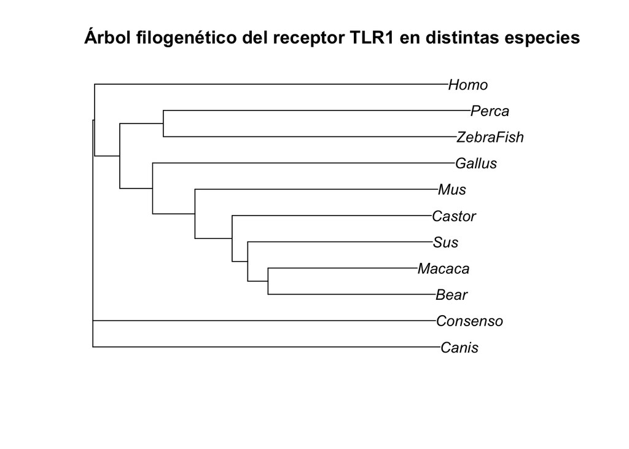

```r
TLRsarbol<-nj(dClu)
plot(TLRsarbol, main="Árbol filogenético del receptor TLR1 en distintas especies")
```